# Week 6 - Weekend Homework

```r
library(tidyverse)
library(infer)

data("msleep")

view(msleep)
```

Question 2. Jabberwockies sleep for around 7 hours a night, on average. Perform an appropriate statistical test to determine whether the mean sleep_total in the sampled population of animal types differs from the typical value for jabberwockies.

H0: mean_sleep_total == 7 Ha: mean_sleep_total != 7

significance level: 0.05

```r
# calculate mean_sleep_total
observed_stat_sleep <- msleep %>%
  summarise(mean_sleep_total = mean(sleep_total))

observed_stat_sleep
```

| mean_sleep_total |
| --- |
| 10.43373 |

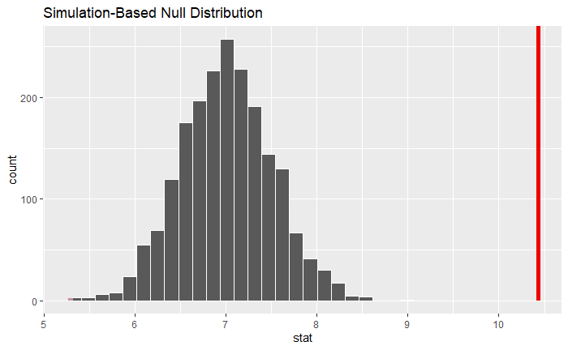

```r
# generate NULL distribution
null_distribution_sleep <- msleep %>%
  specify(response = sleep_total) %>%
  hypothesise(null = "point", mu = 7) %>%
  generate(reps = 2000, type = "bootstrap") %>%
  calculate(stat = "mean")

null_distribution_sleep %>%
  visualise(bins = 25) +
  shade_p_value(obs_stat = observed_stat_sleep,
                direction = "both")
```

```r
null_distribution_sleep %>%
  get_p_value(obs_stat = observed_stat_sleep,
                direction = "both") %>%
  pull() %>%
  format.pval()
```

```
[1] "< 2.22e-16"
```

Given that the p-value is lower than the significance level (almost 0% against 5%), We may reject H0 in favour of the alternative hypothesis that the mean sleep total is different to that of the jabberwocky _________________________________________ Question 3. Perform an appropriate statistical test to determine whether omnivores sleep for significantly longer than herbivores, on average.

significance level: 0.05

```r
# calculate mean_sleep_total for omnivores
observed_stat_sleep_omni <- msleep %>%
  group_by(vore) %>%
  summarise(mean_sleep_total = mean(sleep_total)) %>%
  filter(vore == "omni") %>%
  select(mean_sleep_total)

observed_stat_sleep_herbi <- msleep %>%
  group_by(vore) %>%
  summarise(mean_sleep_total = mean(sleep_total)) %>%
  filter(vore == "herbi") %>%
  select(mean_sleep_total)

observed_stat_sleep_omni
```

| mean_sleep_total |
| --- |
| 10.925 |

```r
observed_stat_sleep_herbi
```

| mean_sleep_total |
| --- |
| 9.509375 |

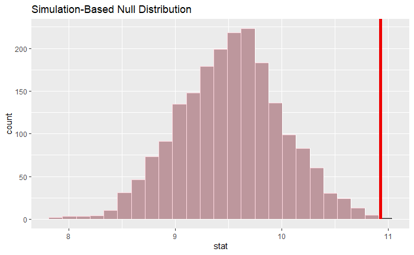

```r
# generate NULL distribution
null_distribution_sleep2 <- msleep %>%
  specify(response = sleep_total) %>%
  hypothesise(null = "point", mu = observed_stat_sleep_herbi$mean_sleep_total) %>%
  generate(reps = 2000, type = "bootstrap") %>%
  calculate(stat = "mean")

null_distribution_sleep2 %>%
  visualise(bins = 25) +
  shade_p_value(obs_stat = observed_stat_sleep_omni,
                direction = "less")
```

```r
null_distribution_sleep %>%
  get_p_value(obs_stat = observed_stat_sleep_omni,
                direction = "less")
```

[output not shown]

Given that our p value is 1, which is higher than our significance level of 0.05, we cannot reject H0

Question 4. Perform an appropriate statistical test to determine whether the proportion of domesticated animal types in the population of animal types is greater than 5%.

H0: prop_domesticated <= 0.05 Ha: prop_domesticated > 0.05

Significance level : 0.05

```r
domesticated_stat
```

```
[1] 0.1204819
```

[figure not shown]

[output not shown]

p value is 0.011 (1.1%) which is lower than significance level of 0.05 (5%) The probability of an animal being domesticated is 0.1204819 (12%) - If H0 is true, this only happens 1.1% of the time. We can reject H0 in favour of Ha ________________________________

1.2

1. One sample proportion test H0: prop_knows_coffee_shop <= 0.4 Ha: prop_knows_coffee_shop > 0.4 Draw
2. Paired two sample mean test H0: click_through_A == click_through_B Ha: click_through_A != click_through_B Bootstrap
3. One sample mean test H0: mean_width == 145mm Ha: mean_width != 145mm bootstrap

1.3

1. p value > significance level - We therefore cannot reject H0 (that less than or equal to 40% of people know of coffee shop) in favour of Ha (more than 40% know)
2. p value < significance level - We can therefore reject H0 (click through rate is the same for both tests) in favour of Ha (one is more successful than the other)
3. p values > significance level - We therefore cannot reject H0 (the average mean width of parts is 145mm) in favour of Ha (average width of parts is different to 145mm)